# Лабораторная работа №6

Операционные системы

Игнатенко Д. Б.

Российский университет дружбы народов, Москва, Россия

19 марта 2026

# Информация

## Докладчик

- Игнатенко Денис Беньяминович
- Студент группы НПИбд-01-25
- Российский университет дружбы народов
- 1032252476@rudn.ru

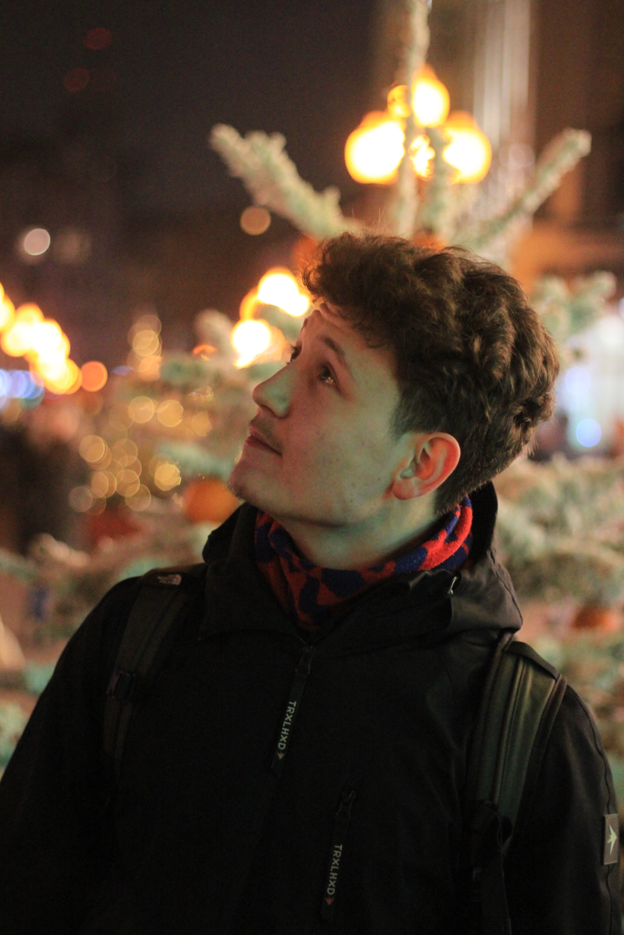

# Цель работы

Приобретение практических навыков взаимодействия пользователя с системой посредством командной строки.

# Задание

- Определить полное имя домашнего каталога
- Выполнить действия с каталогом /tmp
- Создать и удалить каталоги
- Изучить опции команды ls через man
- Просмотреть описание команд cd, pwd, mkdir, rmdir, rm
- Использовать history для модификации команд

# Выполнение лабораторной работы

## Определение домашнего каталога

Определяю полное имя домашнего каталога командой pwd.

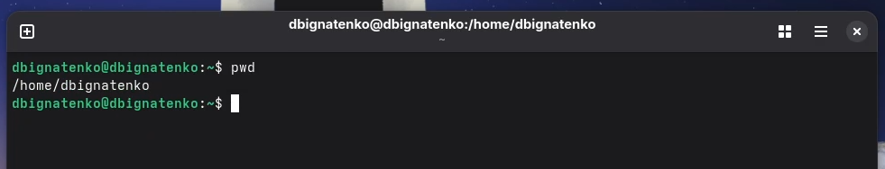

Домашний каталог

## Переход в /tmp

Перехожу в каталог /tmp и проверяю местоположение.

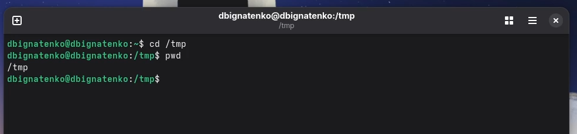

Переход в /tmp

## Содержимое /tmp (ls)

Вывожу содержимое каталога /tmp командой ls.

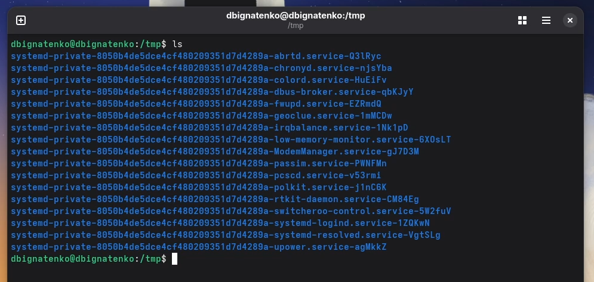

ls

## Содержимое /tmp (ls -a)

Вывожу содержимое включая скрытые файлы.

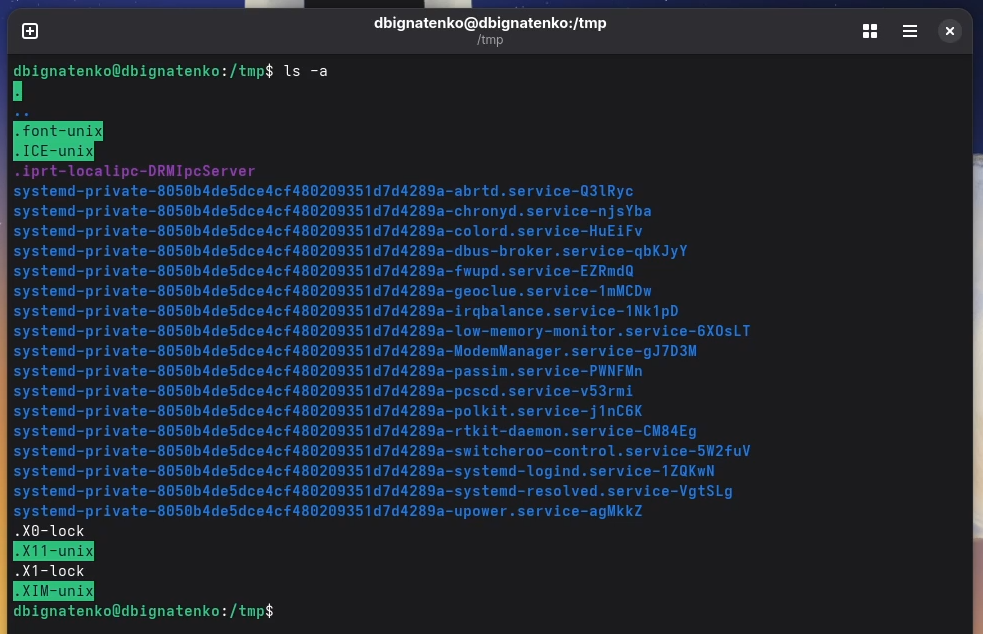

ls -a

## Содержимое /tmp (ls -l)

Вывожу подробную информацию о файлах.

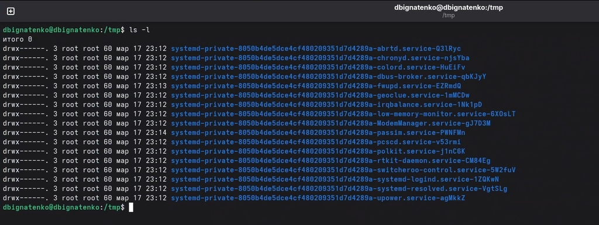

ls -l

## Содержимое /tmp (ls -alF)

Комбинированный вывод с указанием типов файлов.

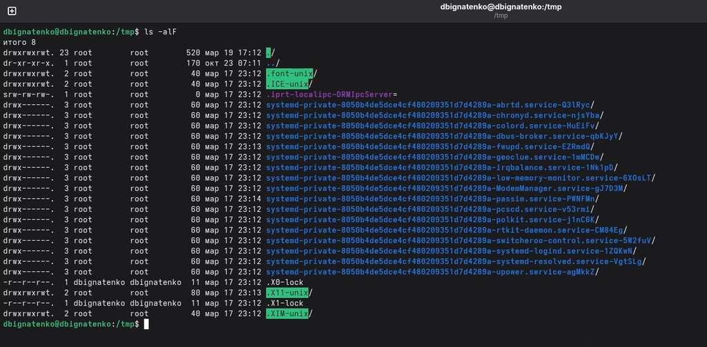

ls -alF

## Проверка /var/spool/cron

Проверяю наличие подкаталога cron в /var/spool.

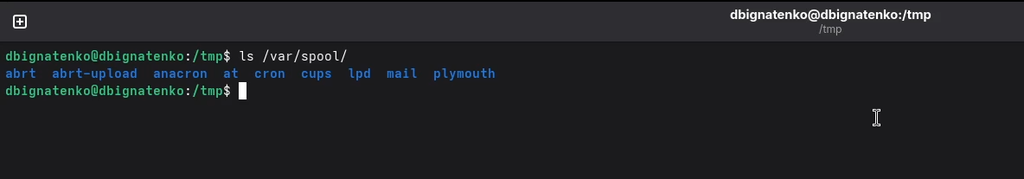

Содержимое /var/spool

## Домашний каталог и владелец

Перехожу в домашний каталог и определяю владельца файлов.

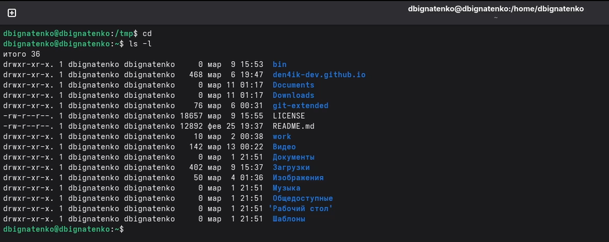

Домашний каталог ls -l

## Создание каталогов

Создаю каталог newdir и подкаталог morefun.

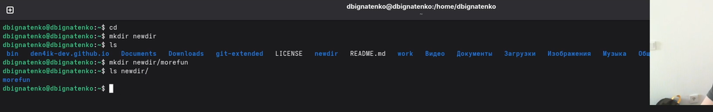

Создание newdir и morefun

## Создание и удаление каталогов

Создаю три каталога одной командой и удаляю их.

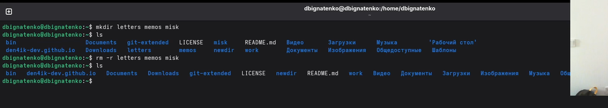

mkdir letters memos misk и rm -r

## Попытка удаления rm без -r

Команда rm без опций не может удалить каталог.

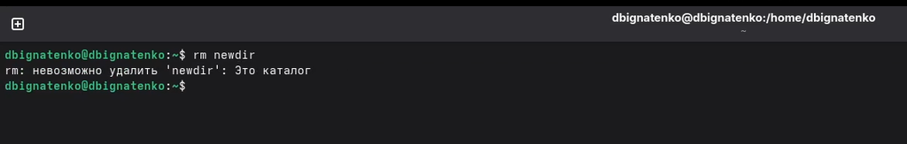

Ошибка rm newdir

## Удаление каталогов

Удаляю morefun и newdir с опцией -r.

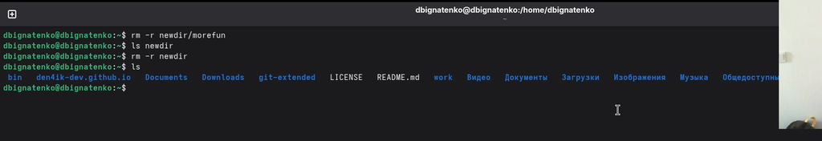

Удаление rm -r

## man ls — опция -R

Определяю опцию для рекурсивного просмотра.

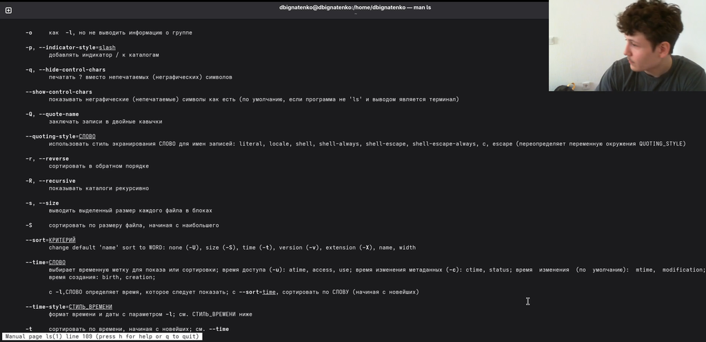

man ls — опция -R

## ls -R демонстрация

Демонстрирую рекурсивный просмотр /etc/cron.d.

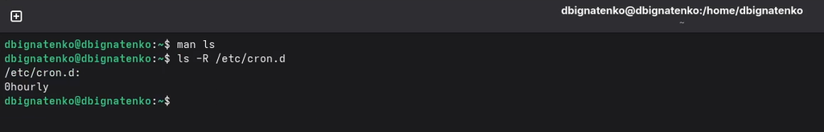

ls -R /etc/cron.d

## man ls — опция -t

Определяю опции для сортировки по времени.

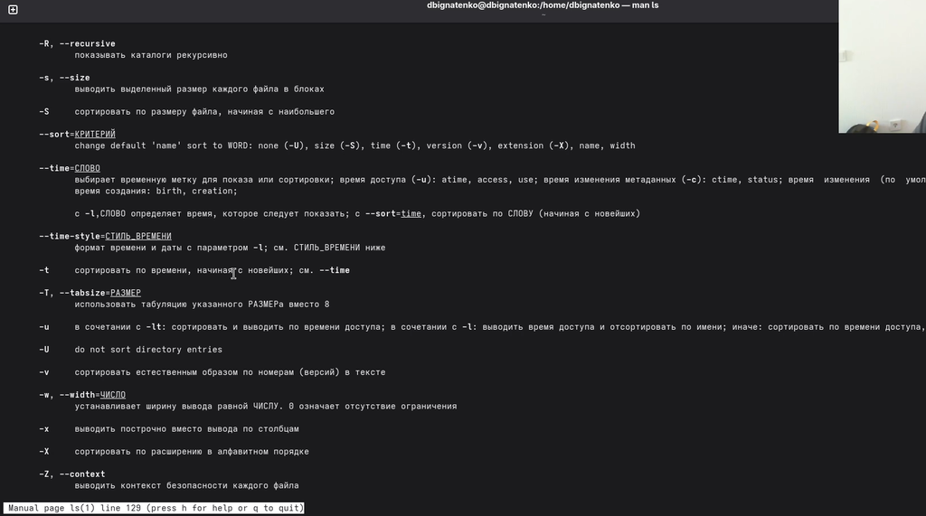

man ls — сортировка по времени

## ls -lt демонстрация

Вывожу содержимое домашнего каталога с сортировкой по времени.

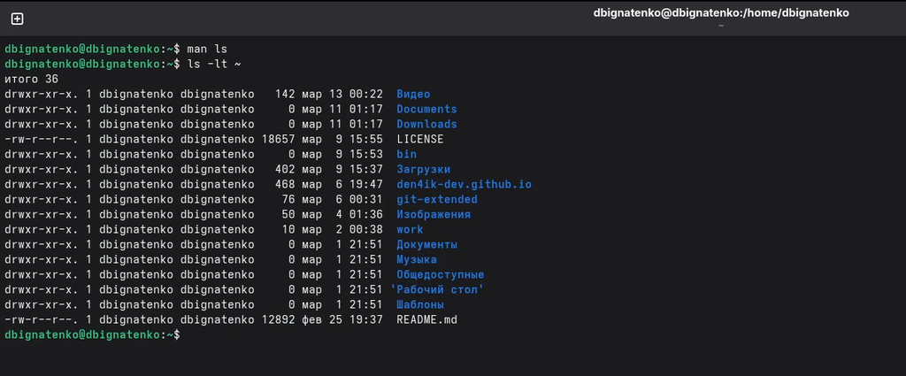

ls -lt ~

## man cd

Просматриваю справку по команде cd.

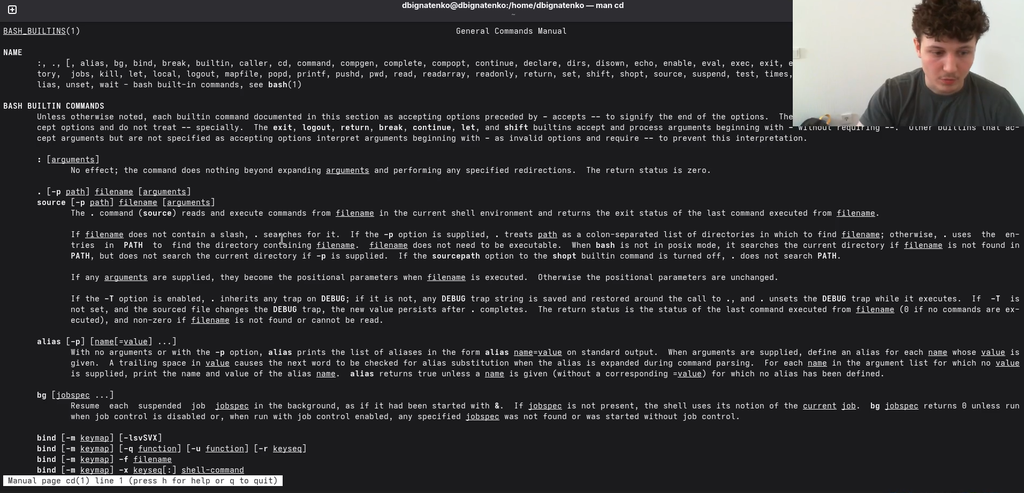

man cd

## man pwd

Просматриваю справку по команде pwd.

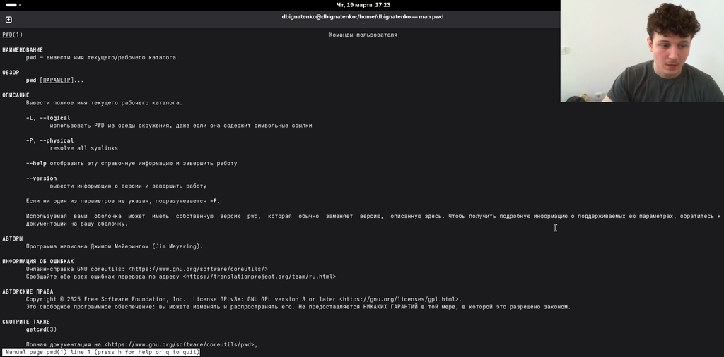

man pwd

## man mkdir

Просматриваю справку по команде mkdir.

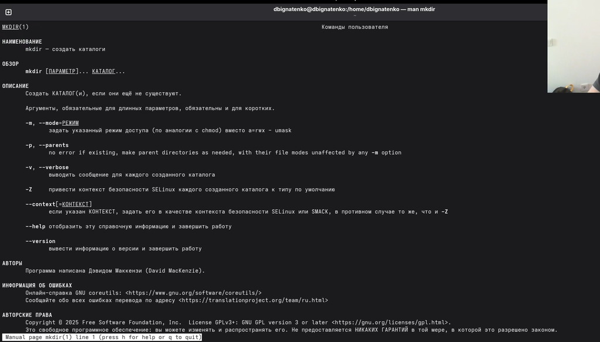

man mkdir

## man rmdir

Просматриваю справку по команде rmdir.

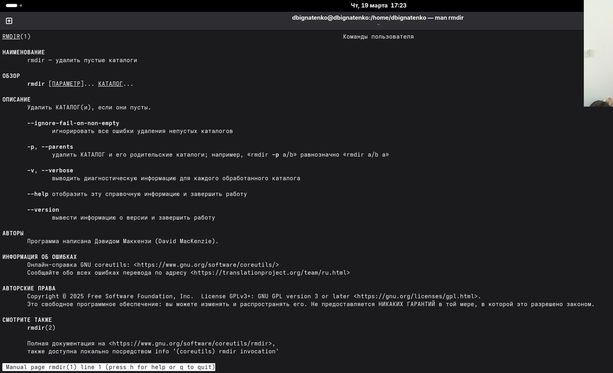

man rmdir

## man rm

Просматриваю справку по команде rm.

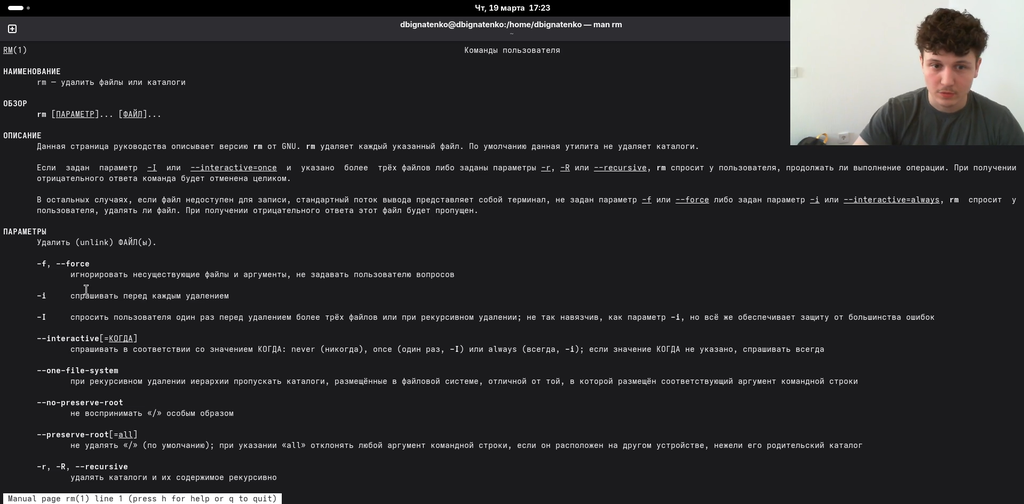

man rm

## history

Вывожу историю команд.

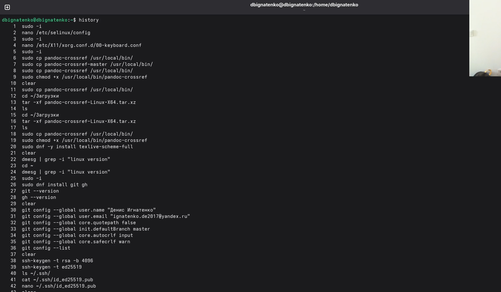

history

## Модификация команды из истории

Выполняю модификацию команды: заменяю -a на -F.

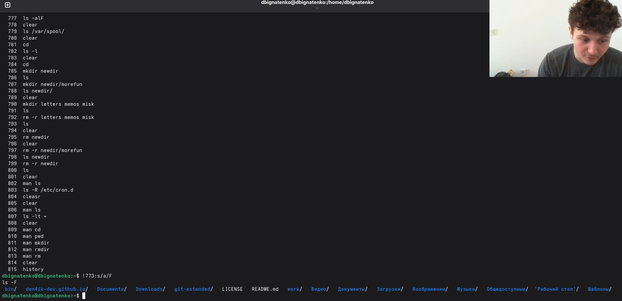

Модификация команды

# Выводы

В ходе выполнения лабораторной работы приобрёл практические навыки взаимодействия с системой посредством командной строки. Освоил команды навигации (cd, pwd), просмотра каталогов (ls), создания и удаления каталогов (mkdir, rm), получения справки (man) и работы с историей команд (history).